# 01 — Customer Profiles (Logistic Regression)

## Mục tiêu & phạm vi

- Xếp hạng khách hàng theo **xác suất “yes”** và rút **insight hành động** từ đặc điểm cá nhân.
- Biến sử dụng: `age, job, education, marital, housing, loan, default, y` *(không dùng `duration` khi train)*.

**Chiến lược đánh giá:** `cv5_test20`

**Chuẩn chung:**

- CSV đọc với `sep=';'`, map target `y: yes/no → 1/0`.
- Giữ nhãn `"unknown"` như 1 giá trị hợp lệ.
- Tránh leakage: **không dùng `duration`** trong mô hình triển khai.

## Phần 1: Chuẩn bị & Đọc dữ liệu

- Mục tiêu: nạp dữ liệu, chuẩn hoá target `y → y_bin`, chọn cột personal.
- Quy ước: không dùng `duration` khi train (tránh leakage).

```
Columns: ['age', 'job', 'marital', 'education', 'default', 'housing', 'loan', 'y', 'y_bin']
Shape: (41188, 9)
```

|  | age | job | marital | education | default | housing | loan | y | y_bin |
| --- | --- | --- | --- | --- | --- | --- | --- | --- | --- |
| 0 | 56 | housemaid | married | basic.4y | no | no | no | no | 0 |
| 1 | 57 | services | married | high.school | unknown | no | no | no | 0 |
| 2 | 37 | services | married | high.school | no | yes | no | no | 0 |
| 3 | 40 | admin. | married | basic.6y | no | no | no | no | 0 |
| 4 | 56 | services | married | high.school | no | no | yes | no | 0 |

## Phần 2: Kiểm tra & Phân tích tần suất

- Kiểm tra: tỉ lệ lớp, null, tỷ lệ "unknown", phạm vi tuổi.
- Tần suất/phân bố: đếm & tỷ lệ (%) cho các biến phân loại (job, education, marital, housing, loan, default, y).

```
Class distribution (%):
 y_bin
no     88.73
yes    11.27
Name: proportion, dtype: float64

Unique counts (categorical):
job       : 12 labels
marital   : 4 labels
education : 8 labels
default   : 3 labels
housing   : 3 labels
loan      : 3 labels
y         : 2 labels

Age describe:
```

```
count    41188.00000
mean        40.02406
std         10.42125
min         17.00000
1%          23.00000
5%          26.00000
25%         32.00000
50%         38.00000
75%         47.00000
95%         58.00000
99%         71.00000
max         98.00000
Name: age, dtype: float64
```

```
Nulls per column:
 age          0
job          0
marital      0
education    0
default      0
housing      0
loan         0
y            0
y_bin        0
dtype: int64

'unknown' rate (%) by column:
 {'job': np.float64(0.8), 'marital': np.float64(0.19), 'education': np.float64(4.2), 'default': np.float64(20.87), 'housing': np.float64(2.4), 'loan': np.float64(2.4)}

Age bounds: {'min': 17, 'p1': 23.0, 'p99': 71.0, 'max': 98}
```

```
job — frequency:
```

|  | job | count | ratio (%) |
| --- | --- | --- | --- |
| 0 | admin. | 10422 | 25.30 |
| 1 | blue-collar | 9254 | 22.47 |
| 2 | technician | 6743 | 16.37 |
| 3 | services | 3969 | 9.64 |
| 4 | management | 2924 | 7.10 |
| 5 | retired | 1720 | 4.18 |
| 6 | entrepreneur | 1456 | 3.54 |
| 7 | self-employed | 1421 | 3.45 |
| 8 | housemaid | 1060 | 2.57 |
| 9 | unemployed | 1014 | 2.46 |
| 10 | student | 875 | 2.12 |
| 11 | unknown | 330 | 0.80 |

```
education — frequency:
```

|  | education | count | ratio (%) |
| --- | --- | --- | --- |
| 0 | university.degree | 12168 | 29.54 |
| 1 | high.school | 9515 | 23.10 |
| 2 | basic.9y | 6045 | 14.68 |
| 3 | professional.course | 5243 | 12.73 |
| 4 | basic.4y | 4176 | 10.14 |
| 5 | basic.6y | 2292 | 5.56 |
| 6 | unknown | 1731 | 4.20 |
| 7 | illiterate | 18 | 0.04 |

```
marital — frequency:
```

|  | marital | count | ratio (%) |
| --- | --- | --- | --- |
| 0 | married | 24928 | 60.52 |
| 1 | single | 11568 | 28.09 |
| 2 | divorced | 4612 | 11.20 |
| 3 | unknown | 80 | 0.19 |

```
housing — frequency:
```

|  | housing | count | ratio (%) |
| --- | --- | --- | --- |
| 0 | yes | 21576 | 52.38 |
| 1 | no | 18622 | 45.21 |
| 2 | unknown | 990 | 2.40 |

```
loan — frequency:
```

|  | loan | count | ratio (%) |
| --- | --- | --- | --- |
| 0 | no | 33950 | 82.43 |
| 1 | yes | 6248 | 15.17 |
| 2 | unknown | 990 | 2.40 |

```
default — frequency:
```

|  | default | count | ratio (%) |
| --- | --- | --- | --- |
| 0 | no | 32588 | 79.12 |
| 1 | unknown | 8597 | 20.87 |
| 2 | yes | 3 | 0.01 |

```
y — frequency:
```

|  | y | count | ratio (%) |
| --- | --- | --- | --- |
| 0 | no | 36548 | 88.73 |
| 1 | yes | 4640 | 11.27 |

### Nhận xét tần suất & chất lượng dữ liệu (Customer Profiles)

**Tổng quan**

- 41,188 bản ghi, không có null. Lớp mục tiêu mất cân bằng: **yes 11.27%**, **no 88.73%**.

**Phân bố theo biến danh mục**

- **job (12 nhãn):** nhóm đông nhất: `admin.` (25.3%), `blue-collar` (22.47%), `technician` (16.37%).  
  Nhãn hiếm: `illiterate` không xuất hiện ở job; tuy nhiên `student` (2.12%), `unemployed` (2.46%), `housemaid` (2.57%), `unknown` (0.8%) là các nhóm nhỏ → giữ nguyên, chỉ cân nhắc gộp “other” nếu cần ổn định hệ số khi train.
- **education (8 nhãn):** `university.degree` (29.54%) và `high.school` (23.10%) chiếm hơn nửa tập;  
  `illiterate` cực hiếm (**0.04%**, 18 bản ghi) → có thể gộp với nhóm “basic.*” hoặc giữ riêng (tác động thấp).  
  `unknown` ở mức **4.2%** → giữ như nhãn hợp lệ để quan sát hành vi.
- **marital (4 nhãn):** `married` (60.52%) chiếm đa số; `single` (28.09%), `divorced` (11.20%), `unknown` rất ít (0.19%).  
  → Biến đủ sạch cho phân tích %yes theo trạng thái hôn nhân.
- **housing (3 nhãn):** `yes` (52.38%) nhỉnh hơn `no` (45.21%); `unknown` **2.4%** → giữ lại để đối chiếu.
- **loan (3 nhãn):** đa số `no` (82.43%); `yes` (15.17%); `unknown` **2.4%**.  
  → Kết hợp với `housing` để tìm nhóm “ít ràng buộc nợ”.
- **default (3 nhãn):** `no` (79.12%), **`unknown` 20.87%**, `yes` chỉ **3 bản ghi (0.01%)**.  
  → Phần “unknown” lớn **không phải lỗi** mà là thiếu thông tin nghiệp vụ; cần **giữ riêng**. Nhãn `default=yes` quá hiếm → mô hình khó học hệ số riêng, nên tập trung so sánh `no` vs `unknown`.
- **age (numeric):** min 17, p1=23, median=38, p75=47, p99=71, max 98 → phân bố hợp lý, không có outlier dị thường; sẽ **chuẩn hoá** khi vào Logistic và dùng **age band** cho EDA.

**Kết luận:** Dữ liệu sạch, chỉ mất cân bằng lớp và `default` có nhiều “unknown”; vì vậy chuyển sang tính **%yes theo các phân khúc** (age band, job/education, marital/housing/loan/default) rồi huấn luyện **Logistic (One-Hot + scale age, class_weight='balanced')** để xếp hạng khách hàng.

[output not shown]

## Phần 3: EDA — Conversion by Segment (3 insight)

- Tính **%yes** theo các phân khúc:
  1. Nhân khẩu học: `age_band`, `job`, `education`
  2. Gia đình: `marital`
  3. Tài chính/rủi ro: `housing`, `loan`, `default`

|  | age_band | total | yes_count | yes_ratio (%) |
| --- | --- | --- | --- | --- |
| 0 | ≤25 | 1666 | 349 | 20.95 |
| 3 | >50 | 7180 | 1082 | 15.07 |
| 1 | 26–35 | 14847 | 1740 | 11.72 |
| 2 | 36–50 | 17495 | 1469 | 8.40 |

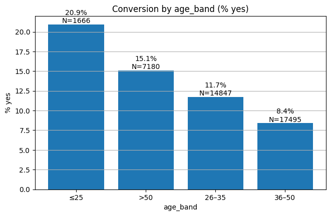

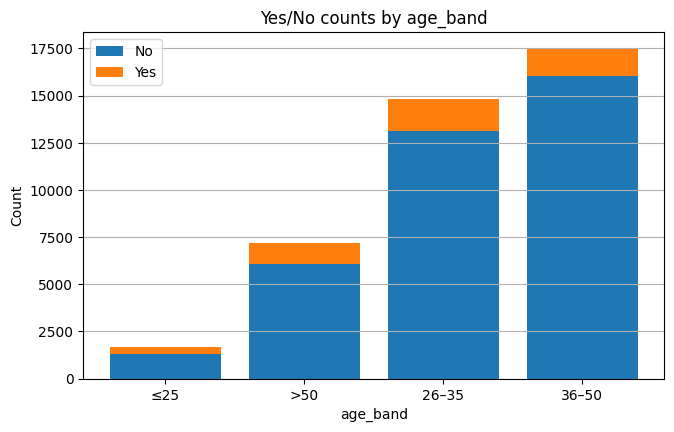

### Nhận xét — %yes theo **age_band**

**Kết quả nổi bật**

- **≤25: 20.95%** (349/1,666) — **cao nhất**, nhưng quy mô nhỏ.
- **>50: 15.07%** (1,082/7,180) — tỷ lệ tốt và **quy mô khá lớn**.
- **26–35: 11.72%** (1,740/14,847) — gần mức chung (≈11.27%) nhưng **đem lại nhiều “yes” tuyệt đối nhất**.
- **36–50: 8.40%** (1,469/17,495) — **thấp nhất**, lại là nhóm đông nhất.

**Ý nghĩa/So what**

- Nếu tối ưu **tỷ lệ**: ưu tiên **≤25** và **>50**.
- Nếu tối ưu **số lượng “yes” tuyệt đối**: đẩy mạnh **26–35** (nền khách lớn).
- Nhóm **36–50** nên **điều chỉnh kịch bản** (nhấn mạnh an toàn/lợi suất/ưu đãi) hoặc kết hợp lọc thêm theo **job/education** để tìm “pocket” tiềm năng.

**Lưu ý**

- Kiểm tra **ý nghĩa thống kê** giữa các band (z-test tỉ lệ) trước khi chốt phân bổ.
- Có thể có **tương tác** với nghề/học vấn hoặc mùa vụ; đừng quyết định chỉ theo tuổi.

**Hành động đề xuất**

- Chạy thêm bảng **%yes theo (age_band × job)** và **(age_band × education)**.
- Chuẩn bị 2 kịch bản telesales:
  - **Trẻ (≤25)**: nhấn mạnh **mục tiêu tài chính sớm/ưu đãi**.
  - **Lớn tuổi (>50)**: nhấn **an toàn/lãi suất ổn định**.
- Với **36–50**, thử **thời điểm gọi/kênh** và ưu đãi phù hợp trước khi giảm ưu tiên.

```
Conversion by job:
```

|  | job | total | yes_count | yes_ratio (%) |
| --- | --- | --- | --- | --- |
| 8 | student | 875 | 275 | 31.43 |
| 5 | retired | 1720 | 434 | 25.23 |
| 10 | unemployed | 1014 | 144 | 14.20 |
| 0 | admin. | 10422 | 1352 | 12.97 |
| 4 | management | 2924 | 328 | 11.22 |
| 11 | unknown | 330 | 37 | 11.21 |
| 9 | technician | 6743 | 730 | 10.83 |
| 6 | self-employed | 1421 | 149 | 10.49 |
| 3 | housemaid | 1060 | 106 | 10.00 |
| 2 | entrepreneur | 1456 | 124 | 8.52 |
| 7 | services | 3969 | 323 | 8.14 |
| 1 | blue-collar | 9254 | 638 | 6.89 |

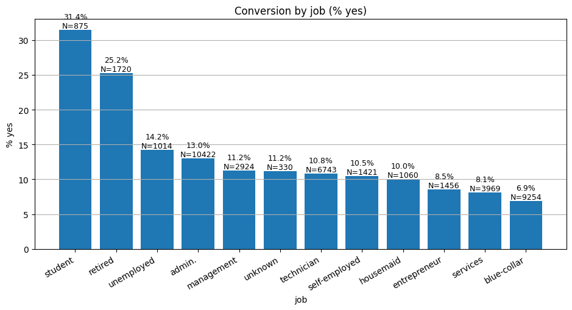

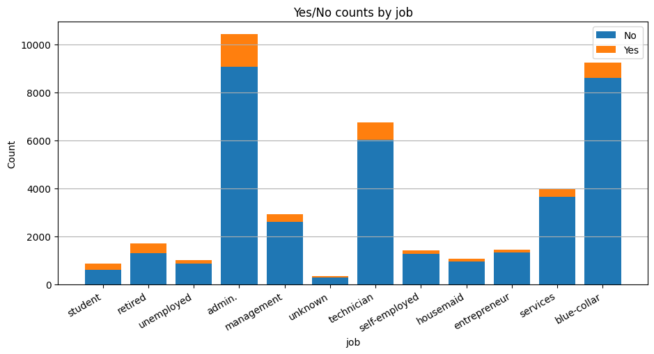

```
Conversion by education:
```

|  | education | total | yes_count | yes_ratio (%) |
| --- | --- | --- | --- | --- |
| 4 | illiterate | 18 | 4 | 22.22 |
| 7 | unknown | 1731 | 251 | 14.50 |
| 6 | university.degree | 12168 | 1670 | 13.72 |
| 5 | professional.course | 5243 | 595 | 11.35 |
| 3 | high.school | 9515 | 1031 | 10.84 |
| 0 | basic.4y | 4176 | 428 | 10.25 |
| 1 | basic.6y | 2292 | 188 | 8.20 |
| 2 | basic.9y | 6045 | 473 | 7.82 |

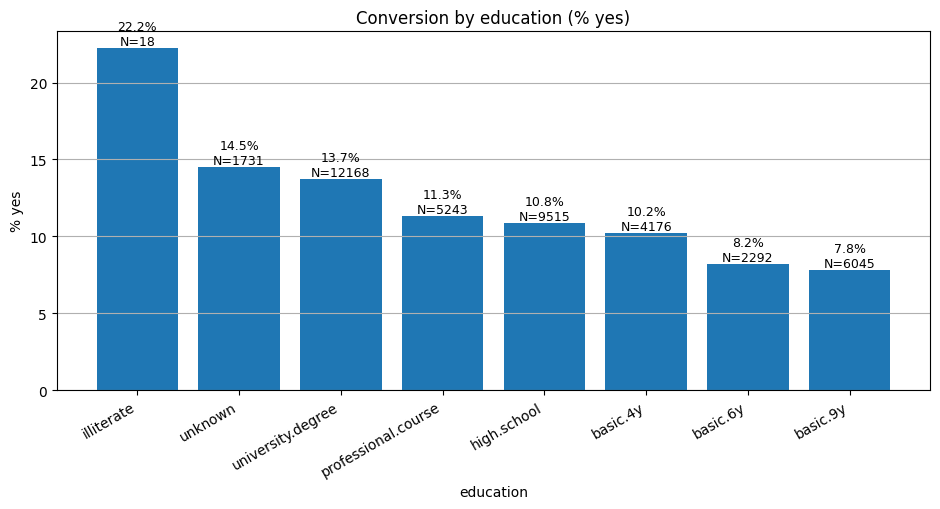

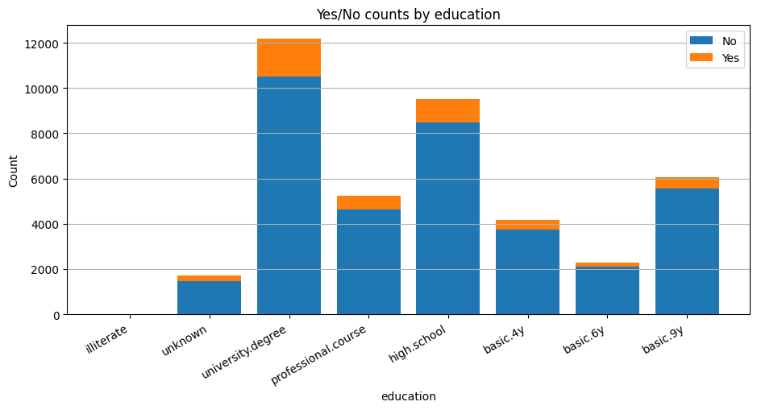

### Nhận xét — Conversion theo **job** & **education**

**Job**

- **Cao nhất:** `student` **31.43%** (N=875) và `retired` **25.23%** (N=1,720) → tỷ lệ rất tốt; `retired` có quy mô khá.
- **Quy mô lớn, tỷ lệ ổn:** `admin.` **12.97%** (N=10,422) → đóng góp **nhiều “yes” tuyệt đối**; `technician` **10.83%** (N=6,743).
- **Thấp nhất:** `blue-collar` **6.89%** (N=9,254) → cần **kịch bản riêng** hoặc **giảm ưu tiên** nếu tối ưu tỷ lệ.
- **Khác:** `unemployed` **14.20%** (N=1,014) đáng chú ý; `services` **8.14%** (N=3,969).

**Education**

- **Cao nhưng nhỏ mẫu:** `illiterate` **22.22%** (N=18) → **không kết luận** từ mẫu quá nhỏ.
- **Mục tiêu tốt & lớn mẫu:** `university.degree` **13.72%** (N=12,168) → vừa **tỷ lệ tốt** vừa **quy mô lớn** → nhóm **ưu tiên**.
- `unknown` **14.50%** (N=1,731) cao hơn trung bình → **giữ tách riêng** khi mô hình hóa.
- **Thấp:** `basic.9y` **7.82%** (N=6,045), `basic.6y` **8.20%** → cân nhắc **giảm ưu tiên** hoặc cá nhân hóa ưu đãi.

**So what**

- Nếu tối ưu **tỷ lệ**: tập trung `student`, `retired`, `unemployed` và `university.degree`.
- Nếu tối ưu **số lượng “yes”**: `admin.` và `university.degree` vì **nền khách lớn**.
- `blue-collar` và nhóm **basic.*y** cần **điều chỉnh kịch bản** (nhấn lợi ích ngắn hạn/ưu đãi phí) hoặc **giảm tần suất**.

**Lưu ý**

- Kiểm tra **ý nghĩa thống kê** khác biệt giữa nhóm (z-test tỉ lệ).
- Tránh thiên lệch do **mùa vụ/kênh liên hệ**; sẽ kiểm tra thêm giao cắt.

**Hành động kế tiếp**

- Tạo bảng **(age_band × job)** và **(education × job)** để tìm “pocket” có **%yes cao + đủ mẫu** cho chiến dịch ưu tiên.

```
Conversion by marital:
```

|  | marital | total | yes_count | yes_ratio (%) |
| --- | --- | --- | --- | --- |
| 3 | unknown | 80 | 12 | 15.00 |
| 2 | single | 11568 | 1620 | 14.00 |
| 0 | divorced | 4612 | 476 | 10.32 |
| 1 | married | 24928 | 2532 | 10.16 |

[figure not shown]

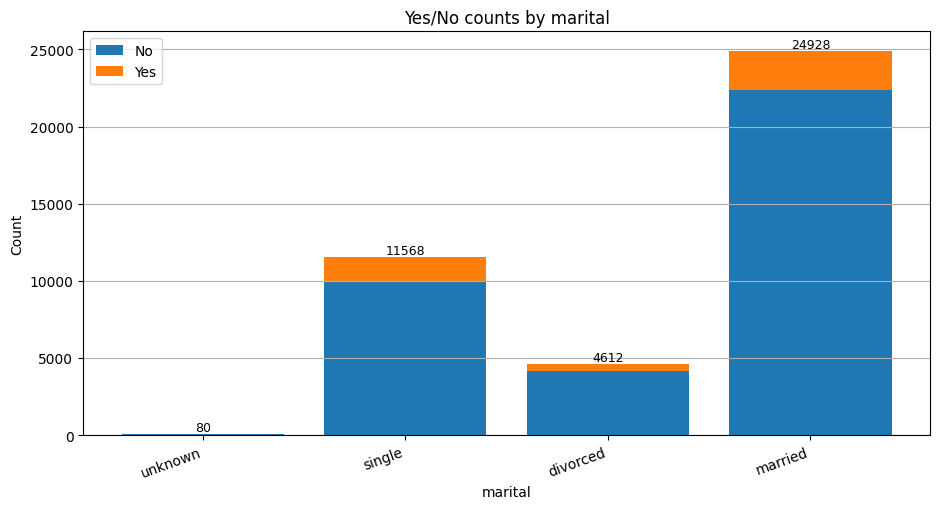

```
Conversion by housing:
```

|  | housing | total | yes_count | yes_ratio (%) |
| --- | --- | --- | --- | --- |
| 2 | yes | 21576 | 2507 | 11.62 |
| 0 | no | 18622 | 2026 | 10.88 |
| 1 | unknown | 990 | 107 | 10.81 |

[figure not shown]

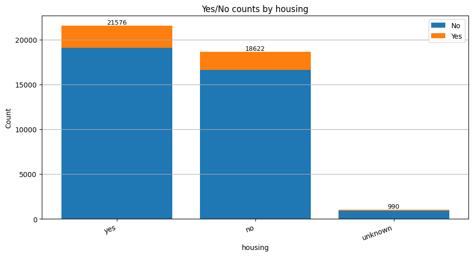

```
Conversion by loan:
```

|  | loan | total | yes_count | yes_ratio (%) |
| --- | --- | --- | --- | --- |
| 0 | no | 33950 | 3850 | 11.34 |
| 2 | yes | 6248 | 683 | 10.93 |
| 1 | unknown | 990 | 107 | 10.81 |

[figure not shown]

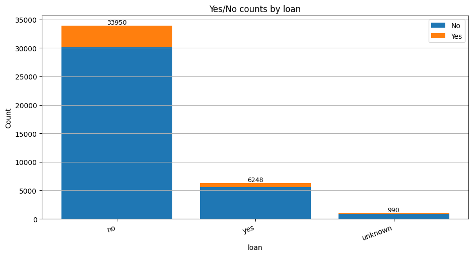

```
Conversion by default (giữ 'unknown'):
```

|  | default | total | yes_count | yes_ratio (%) |
| --- | --- | --- | --- | --- |
| 0 | no | 32588 | 4197 | 12.88 |
| 1 | unknown | 8597 | 443 | 5.15 |
| 2 | yes | 3 | 0 | 0.00 |

[figure not shown]

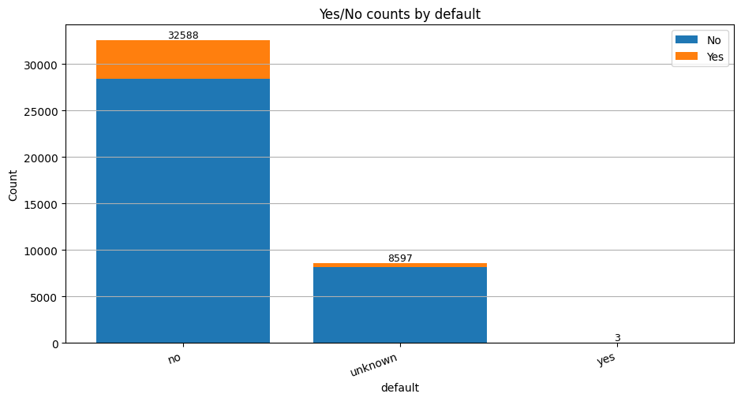

### Nhận xét — Conversion theo **marital / housing / loan / default**

**Marital**

- **single 14.00%** (N=11,568) > divorced 10.32% > married **10.16%**.  
  → **Ưu tiên nhóm single** (tỷ lệ cao hơn rõ rệt). `unknown 15%` nhưng N=80 (quá nhỏ).

**Housing**

- `yes` **11.62%** (N=21,576) nhỉnh hơn `no` **10.88%**; `unknown` **10.81%**.  
  → Khác biệt **nhẹ**, **không đủ** để tách nhóm một mình; nên kết hợp với **age/job**.

**Loan**

- `no` **11.34%** ≈ `yes` **10.93%** (chênh không đáng kể).  
  → **Ít giá trị phân tách** nếu đứng riêng.

**Default (giữ 'unknown')**

- `no` **12.88%** (N=32,588) **>>** `unknown` **5.15%** (N=8,597); `yes` N=3 (0%).  
  → **Tín hiệu mạnh**: ưu tiên khách **default = no**; nhóm **default = unknown** nên **giảm ưu tiên** hoặc cần **kịch bản nuôi dưỡng**.

**So what (ngắn gọn)**

- **Ưu tiên gọi:** `single` + `default=no`.
- **Cần kết hợp thêm điều kiện:** `housing`/`loan` (tự chúng phân tách yếu).
- **Tiếp theo:** kiểm tra giao cắt **(age_band × marital)** và **(default × job/education)** để xác định các “pocket” %yes cao + đủ mẫu.

## Kết luận EDA — Phân khúc ưu tiên

**Ưu tiên theo tỷ lệ &/hoặc quy mô:**

- **Age/Job/Edu:** `student` (31.4%), `retired` (25.2%), `university.degree` (13.7%), **age ≤25** (20.9%), **age >50** (15.1%).
- **Gia đình:** `single` (14.0%) > `married` (10.2%).
- **Tài chính/rủi ro:** `default = no` (12.9%) **>>** `default = unknown` (5.1%).
- **Quy mô lớn đóng góp nhiều yes tuyệt đối:** `admin.` (12.97%, N≈10.4k), `technician` (10.83%, N≈6.7k), `age 26–35` (11.7%, N≈14.8k).

**Hàm ý gọi thử nghiệm:**

- Nhóm trọng tâm: **student / retired / single / university.degree / default=no**.
- Nhóm cần điều chỉnh kịch bản hoặc giảm ưu tiên: **blue-collar**, **basic.*y**, **default=unknown**.

## Phần 4: Chia dữ liệu & cấu hình đánh giá (`cv5_test20`) — PySpark

### Mục tiêu

- Tạo **label** (0/1), cố định `SEED=42`.
- **Stratified split**: Train 80% / Test 20% giữ tỷ lệ lớp.
- In ra quy mô & tỷ lệ lớp của từng tập để kiểm tra.

```
+-----+-----+
|label|count|
+-----+-----+
|    1| 4640|
|    0|36548|
+-----+-----+
```

```
Train/Test sizes:
32950 8238

Class ratio (Train):
+-----+-----+------------------+
|label|count|           ratio_%|
+-----+-----+------------------+
|    0|29238| 88.73444613050076|
|    1| 3712|11.265553869499241|
+-----+-----+------------------+

Class ratio (Test):
+-----+-----+------------------+
|label|count|           ratio_%|
+-----+-----+------------------+
|    0| 7310| 88.73512988589464|
|    1|  928|11.264870114105365|
+-----+-----+------------------+
```

### 4.1 — Spark ML: Dựng pipeline đặc trưng + class weights (chưa train)

```
pos_weight=7.88, grid=8 (regParam in [0.2,0.1,0.05,0.01], elasticNet in [0.0,0.5]), CV=5
```

### Phần 5: Train Logistic (CV=5) — chọn regParam tối ưu

```
25/10/25 14:30:50 WARN BlockManager: Asked to remove block broadcast_6391, which does not exist
```

```
[Best] regParam=0.01, elasticNet=0.0, threshold=0.5
```

|  | regParam | elasticNet | PR_AUC_CV_mean |
| --- | --- | --- | --- |
| 0 | 0.20 | 0.0 | 0.209045 |
| 1 | 0.20 | 0.5 | 0.112645 |
| 2 | 0.10 | 0.0 | 0.209673 |
| 3 | 0.10 | 0.5 | 0.204505 |
| 4 | 0.05 | 0.0 | 0.210062 |
| 5 | 0.05 | 0.5 | 0.196975 |
| 6 | 0.01 | 0.0 | 0.211575 |
| 7 | 0.01 | 0.5 | 0.209211 |

### Phần 5 — Refit mô hình tốt nhất & Đánh giá trên Test (PySpark)

## Refit Logistic (best params) & Evaluate on Test

```
25/10/25 14:32:09 WARN SparkStringUtils: Truncated the string representation of a plan since it was too large. This behavior can be adjusted by setting 'spark.sql.debug.maxToStringFields'.
```

```
+-----+----------------------------------------+-------------------+----------+
|label|probability                             |prob1              |prediction|
+-----+----------------------------------------+-------------------+----------+
|1    |[0.5603285298825881,0.4396714701174119] |0.4396714701174119 |0.0       |
|1    |[0.4227459034373681,0.5772540965626318] |0.5772540965626318 |1.0       |
|1    |[0.14331215470079484,0.8566878452992052]|0.8566878452992052 |1.0       |
|1    |[0.5161601277556834,0.48383987224431657]|0.48383987224431657|0.0       |
|1    |[0.22261162107656476,0.7773883789234353]|0.7773883789234353 |1.0       |
+-----+----------------------------------------+-------------------+----------+
only showing top 5 rows

[TEST] PR-AUC=0.2114 | ROC-AUC=0.6519 | BRIER=0.2273
[TEST @0.5] Precision=0.1636 | Recall=0.6034 | F1=0.2575
Confusion@0.5: TP=560 FP=2862 FN=368 TN=4448
```

## Phần 6A — Refit Logistic (best params) & Đánh giá baseline trên Test

- Dùng **regParam=0.01, elasticNet=0.0 (L2)**, giữ `weightCol`.
- Báo cáo: **PR-AUC**, **ROC-AUC**, **Brier**, **Precision/Recall/F1 @ 0.5**, **Confusion@0.5**.

```
[TEST] PR-AUC=0.2114 | ROC-AUC=0.6519 | BRIER=0.2273
[TEST @0.5] Precision=0.1636 | Recall=0.6034 | F1=0.2575
Confusion@0.5: TP=560 FP=2862 FN=368 TN=4448
```

## Phần 6B — Quét ngưỡng & chọn t*

- Sweep **threshold 0.05 → 0.95** bước 0.05 → bảng **Precision/Recall/F1**.
- Chọn **t*** theo:
  - **(a) Profit(t) = TP·P − (TP+FP)·C** *(điền P, C theo giả định nhóm)*, hoặc
  - **(b) Precision/Recall mục tiêu** *(ví dụ Precision ≥ 0.25, Recall ≥ 0.45)*.
- Báo cáo **Precision/Recall/F1/Confusion @ t***.

```
[t* theo Profit] t* = 0.45 | Profit=218.0000 | Prec=0.1466 | Rec=0.7392 | F1=0.2447 | TP=686 FP=3994 FN=242 TN=3316
[t* theo ràng buộc] Không có ngưỡng thoả **Precision≥0.25 & Recall≥0.45** trên Test.
```

|  | threshold | TP | FP | FN | TN | precision | recall | f1 | profit |
| --- | --- | --- | --- | --- | --- | --- | --- | --- | --- |
| 8 | 0.45 | 686 | 3994 | 242 | 3316 | 0.146581 | 0.739224 | 0.244650 | 218.0 |
| 9 | 0.50 | 560 | 2862 | 368 | 4448 | 0.163647 | 0.603448 | 0.257471 | 217.8 |
| 10 | 0.55 | 427 | 1788 | 501 | 5522 | 0.192777 | 0.460129 | 0.271715 | 205.5 |
| 7 | 0.40 | 777 | 4981 | 151 | 2329 | 0.134943 | 0.837284 | 0.232426 | 201.2 |
| 6 | 0.35 | 832 | 5749 | 96 | 1561 | 0.126425 | 0.896552 | 0.221601 | 173.9 |
| 5 | 0.30 | 861 | 6211 | 67 | 1099 | 0.121748 | 0.927802 | 0.215250 | 153.8 |
| 11 | 0.60 | 268 | 880 | 660 | 6430 | 0.233449 | 0.288793 | 0.258189 | 153.2 |
| 4 | 0.25 | 891 | 6678 | 37 | 632 | 0.117717 | 0.960129 | 0.209721 | 134.1 |
| 12 | 0.65 | 172 | 349 | 756 | 6961 | 0.330134 | 0.185345 | 0.237405 | 119.9 |
| 3 | 0.20 | 921 | 7157 | 7 | 153 | 0.114013 | 0.992457 | 0.204530 | 113.2 |

|  | threshold | TP | FP | FN | TN | precision | recall | f1 | profit |
| --- | --- | --- | --- | --- | --- | --- | --- | --- | --- |
| 10 | 0.55 | 427 | 1788 | 501 | 5522 | 0.192777 | 0.460129 | 0.271715 | 205.5 |
| 11 | 0.60 | 268 | 880 | 660 | 6430 | 0.233449 | 0.288793 | 0.258189 | 153.2 |
| 9 | 0.50 | 560 | 2862 | 368 | 4448 | 0.163647 | 0.603448 | 0.257471 | 217.8 |
| 8 | 0.45 | 686 | 3994 | 242 | 3316 | 0.146581 | 0.739224 | 0.244650 | 218.0 |
| 12 | 0.65 | 172 | 349 | 756 | 6961 | 0.330134 | 0.185345 | 0.237405 | 119.9 |
| 7 | 0.40 | 777 | 4981 | 151 | 2329 | 0.134943 | 0.837284 | 0.232426 | 201.2 |
| 6 | 0.35 | 832 | 5749 | 96 | 1561 | 0.126425 | 0.896552 | 0.221601 | 173.9 |
| 5 | 0.30 | 861 | 6211 | 67 | 1099 | 0.121748 | 0.927802 | 0.215250 | 153.8 |
| 13 | 0.70 | 137 | 241 | 791 | 7069 | 0.362434 | 0.147629 | 0.209801 | 99.2 |
| 4 | 0.25 | 891 | 6678 | 37 | 632 | 0.117717 | 0.960129 | 0.209721 | 134.1 |

## Phần 6C — Giải thích Logistic: hệ số & Odds Ratio (top + / -)

- Trích hệ số `coef` từ model đã refit (best).
- Map hệ số về **tên đặc trưng** (age_std, age_band, job=…, education=…, …).
- Tính **odds ratio = exp(coef)**; liệt kê **top 10 dương** và **top 10 âm**.

```
Top 10 hệ số dương (tăng odds yes):
```

|  | feature | coef | odds_ratio |
| --- | --- | --- | --- |
| 0 | job=student | 0.957412 | 2.604945 |
| 1 | age_band=≤25 | 0.689672 | 1.993062 |
| 2 | job=retired | 0.536362 | 1.709776 |
| 3 | education=illiterate | 0.467453 | 1.595925 |
| 4 | default=no | 0.437269 | 1.548472 |
| 5 | job=unemployed | 0.288618 | 1.334581 |
| 6 | age_std | 0.220013 | 1.246093 |
| 7 | age_band=26–35 | 0.174906 | 1.191134 |
| 8 | marital=unknown | 0.174224 | 1.190322 |
| 9 | education=university.degree | 0.158099 | 1.171283 |

```
Top 10 hệ số âm (giảm odds yes):
```

|  | feature | coef | odds_ratio |
| --- | --- | --- | --- |
| 0 | default=yes | -3.081636 | 0.045884 |
| 1 | default=unknown | -0.436190 | 0.646495 |
| 2 | job=services | -0.266048 | 0.766402 |
| 3 | job=blue-collar | -0.263907 | 0.768045 |
| 4 | job=entrepreneur | -0.260655 | 0.770547 |
| 5 | age_band=36–50 | -0.235374 | 0.790275 |
| 6 | education=basic.9y | -0.214544 | 0.806909 |
| 7 | marital=divorced | -0.155757 | 0.855767 |
| 8 | education=basic.4y | -0.105105 | 0.900230 |
| 9 | job=housemaid | -0.101783 | 0.903225 |

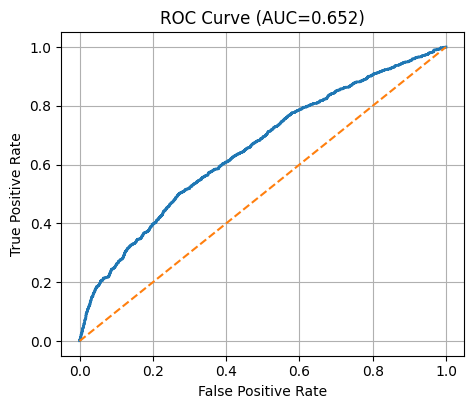

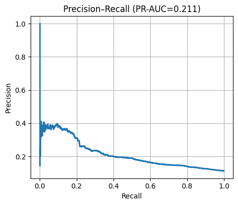

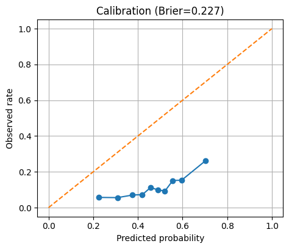

[figure not shown]

```
[t*=0.45] TP=686 FP=3994 FN=242 TN=3316 | Prec=0.147 Rec=0.739 F1=0.245 | Brier=0.2273
```

|  | decile | N | Yes | Rate | CumYes | CumPct | Lift |
| --- | --- | --- | --- | --- | --- | --- | --- |
| 0 | D1 | 824 | 216 | 0.262136 | 216 | 0.232759 | 2.327021 |
| 1 | D2 | 824 | 126 | 0.152913 | 342 | 0.368534 | 1.357429 |
| 2 | D3 | 824 | 125 | 0.151699 | 467 | 0.503233 | 1.346656 |
| 3 | D4 | 823 | 76 | 0.092345 | 543 | 0.585129 | 0.819762 |
| 4 | D5 | 824 | 82 | 0.099515 | 625 | 0.673491 | 0.883406 |
| 5 | D6 | 824 | 92 | 0.111650 | 717 | 0.772629 | 0.991139 |
| 6 | D7 | 823 | 60 | 0.072904 | 777 | 0.837284 | 0.647180 |
| 7 | D8 | 824 | 58 | 0.070388 | 835 | 0.899784 | 0.624848 |
| 8 | D9 | 824 | 46 | 0.055825 | 881 | 0.949353 | 0.495569 |
| 9 | D10 | 824 | 47 | 0.057039 | 928 | 1.000000 | 0.506343 |

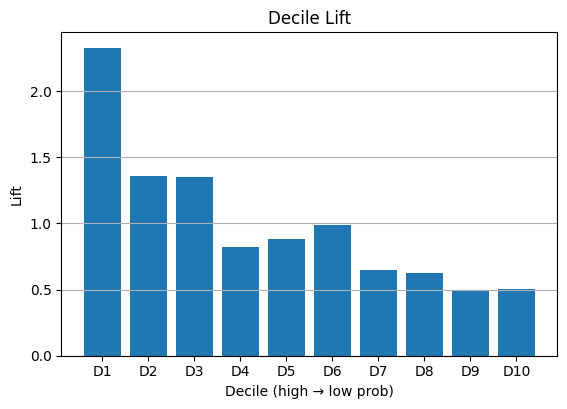

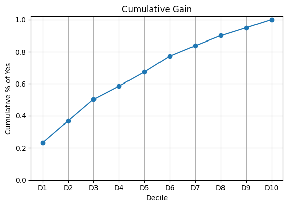

```
SUMMARY | PR_AUC≈0.211 | ROC_AUC≈0.652 | BRIER≈0.227 | t*=0.45 | PREC@t*=0.147 | REC@t*=0.739 | F1@t*=0.245
```

# Đánh giá & Kết luận

## Giải thích mô hình (coef & odds ratio — rút gọn)

- **Tăng odds “yes” (OR>1):** `job=student` (≈2.60×), `age ≤25` (≈1.99×), `job=retired` (≈1.71×), `default=no` (≈1.55×), `education=university.degree` (≈1.17×).
- **Giảm odds “yes” (OR<1):** `default=unknown` (≈0.65×) và **rất thấp** với `default=yes` (~0.046×, nhưng cực hiếm), `job=blue-collar/services`, `age 36–50`, `education=basic.9y`.

## Cách vận hành khuyến nghị

- **Chiến lược gọi theo *decile*** (khuyến khích):
  - Ưu tiên **Top 10–30%** khách (D1–D3): lift cao, **tối ưu hiệu quả/chi phí** hơn so với đặt ngưỡng cứng.
- **Nếu cần ngưỡng duy nhất:** dùng **t* = 0.45** (tối đa hóa profit theo giả định P/C hiện tại) để **giữ recall cao**, chấp nhận nhiều FP.
  - Nếu mục tiêu **nâng precision**, tăng t lên **0.55–0.60** (đổi lại giảm recall & profit).
- **Kịch bản ưu tiên/segment hóa:** tập trung **student, retired, university.degree, default=no**; thận trọng với **default=unknown**, **blue-collar**, **basic.*y**.

## Kết luận

- Mô hình Logistic hiện tại **đạt baseline tốt cho xếp hạng khách hàng** trong chiến dịch telemarketing: **PR-AUC 0.211**, **ROC-AUC 0.652**; **top-decile mang lại lift mạnh** và **t*=0.45** tối ưu profit theo giả định.
- **Sẵn sàng dùng** cho ưu tiên gọi & thử nghiệm A/B theo **decile**/**ngưỡng**; có thể **cải thiện thêm** bằng **calibration** và tinh chỉnh mục tiêu (precision vs. recall) theo KPI kinh doanh.

## Phần 7: Xây dựng & Tinh chỉnh Mô hình — Cây Quyết định (Decision Tree)

Xây dựng một mô hình baseline thứ hai là Cây Quyết định (Decision Tree) để so sánh với Logistic Regression. Mục tiêu chính của DT là tìm ra các **quy tắc kinh doanh trực quan** để phân khúc khách hàng.

### 7A — Cấu hình Pipeline cho Decision Tree

1. **Khởi tạo Trình phân loại:** Import `DecisionTreeClassifier`.
2. **Sử dụng `weightCol`:** Chúng ta sẽ tiếp tục sử dụng `weightCol="weight"` giống như Logistic Regression để xử lý dữ liệu mất cân bằng.
3. **Thiết lập Lưới tham số:** Chúng ta sẽ tinh chỉnh `maxDepth` (độ sâu tối đa) và `maxBins`.
4. **Tạo Pipeline:** Sử dụng lại các bước tiền xử lý (stages) đã có từ pipeline của Logistic Regression.

```
Đã tạo pipeline cho Decision Tree.
Số lượng cấu hình sẽ kiểm tra trong Cross-Validation: 8
```

### 7B — Chạy Cross-Validation (CV=5) — chọn `maxDepth` & `maxBins` tối ưu

Bây giờ chúng ta sẽ chạy Cross-Validation (CV) cho Cây Quyết định.

- **Estimator:** `pipeline_dt` (pipeline đã định nghĩa ở 7A).
- **ParamGrid:** `paramGrid_dt` (lưới tham số `maxDepth` và `maxBins` đã định nghĩa ở 7A).
- **Evaluator:** Chúng ta sẽ **sử dụng lại `evaluator_pr`** (đo lường PR-AUC) đã dùng cho Logistic Regression (LR) để đảm bảo việc so sánh hai mô hình là công bằng.

[output not shown]

```
[Best DT] maxDepth=3, maxBins=32
```

|  | maxDepth | maxBins | PR_AUC_CV_mean |
| --- | --- | --- | --- |
| 0 | 3 | 32 | 0.122084 |
| 1 | 3 | 50 | 0.122077 |
| 2 | 5 | 50 | 0.121937 |
| 3 | 10 | 50 | 0.118392 |
| 4 | 10 | 32 | 0.117857 |
| 5 | 7 | 32 | 0.117432 |
| 6 | 7 | 50 | 0.116553 |
| 7 | 5 | 32 | 0.116131 |

### 7C — Đánh giá Mô hình DT Tốt nhất trên Tập Test

Lấy mô hình tốt nhất (`bestModel` từ `cvModel_dt`) và chạy đánh giá trên `test_df`.

```
Kết quả dự đoán của Decision Tree trên tập Test (top 5):
```

```
+-----+----------------------------------------+------------------+----------+
|label|probability                             |prob1             |prediction|
+-----+----------------------------------------+------------------+----------+
|1    |[0.46175233708361907,0.5382476629163809]|0.5382476629163809|1.0       |
|1    |[0.46175233708361907,0.5382476629163809]|0.5382476629163809|1.0       |
|1    |[0.46175233708361907,0.5382476629163809]|0.5382476629163809|1.0       |
|1    |[0.46175233708361907,0.5382476629163809]|0.5382476629163809|1.0       |
|1    |[0.46175233708361907,0.5382476629163809]|0.5382476629163809|1.0       |
+-----+----------------------------------------+------------------+----------+
only showing top 5 rows

------------------------------
Kết quả Đánh giá Tổng quát Decision Tree (trên tập Test):
[TEST DT] PR-AUC=0.1274 | ROC-AUC=0.5610 | BRIER=0.2419
```

### Quét ngưỡng & Tối ưu Lợi nhuận (DT)

```
[t* theo Profit (DT)] t* = 0.30 | Profit=184.7000 | Prec=0.1286 | Rec=0.8955 | F1=0.2249 | TP=831 FP=5632 FN=97 TN=1678
```

|  | threshold | TP | FP | FN | TN | precision | recall | f1 | profit |
| --- | --- | --- | --- | --- | --- | --- | --- | --- | --- |
| 8 | 0.45 | 831 | 5632 | 97 | 1678 | 0.128578 | 0.895474 | 0.224868 | 184.7 |
| 5 | 0.30 | 831 | 5632 | 97 | 1678 | 0.128578 | 0.895474 | 0.224868 | 184.7 |
| 6 | 0.35 | 831 | 5632 | 97 | 1678 | 0.128578 | 0.895474 | 0.224868 | 184.7 |
| 9 | 0.50 | 831 | 5632 | 97 | 1678 | 0.128578 | 0.895474 | 0.224868 | 184.7 |
| 7 | 0.40 | 831 | 5632 | 97 | 1678 | 0.128578 | 0.895474 | 0.224868 | 184.7 |

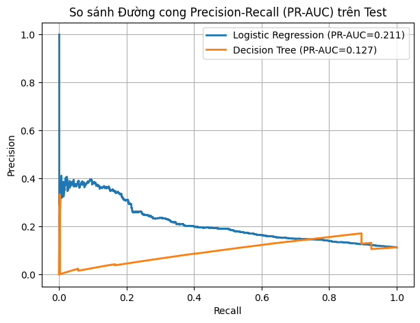

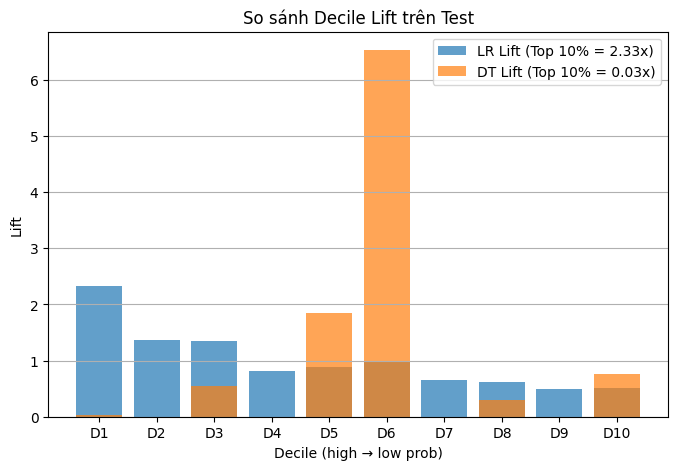

[figure not shown]

```
[t*=0.30 (DT)] TP=831 FP=5632 FN=97 TN=1678 | Prec=0.129 Rec=0.895 F1=0.225
```

### 7D — Giải thích Mô hình DT (Tìm quy tắc kinh doanh)

Phần đánh giá hiệu năng (PR-AUC 0.127 và Lift 0.03x ở D1) cho thấy mô hình Logistic Regression (LR) hoạt động tốt hơn DT (với `maxDepth=3`) trong việc *xếp hạng* (scoring) chi tiết.

Tuy nhiên, mục tiêu chính của DT là để *giải thích* (explainability) và *phân khúc* (segmentation). Chúng ta sẽ xem xét 2 yếu tố:

1. Các đặc trưng quan trọng nhất (Feature Importances).
2. Các quy tắc (rules) mà cây đã học được.

```
Top 10 Đặc trưng Quan trọng nhất (theo Decision Tree):
```

|  | feature | importance |
| --- | --- | --- |
| 40 | default=no | 0.841083 |
| 0 | age_std | 0.154287 |
| 23 | education=basic.6y | 0.004630 |
| 1 | age_band=≤25 | 0.000000 |
| 4 | age_band=>50 | 0.000000 |
| 5 | job=admin. | 0.000000 |
| 6 | job=blue-collar | 0.000000 |
| 7 | job=technician | 0.000000 |
| 8 | job=services | 0.000000 |
| 9 | job=management | 0.000000 |

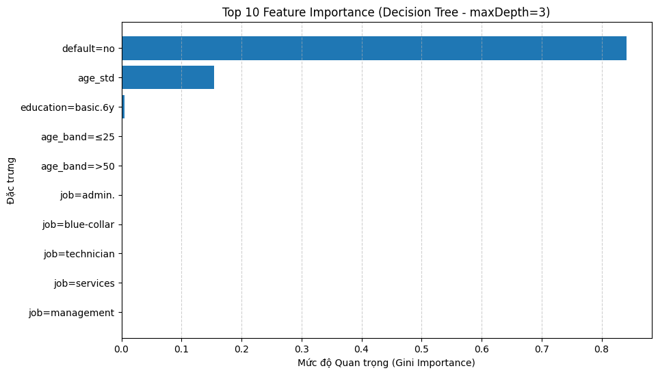

```
Cấu trúc Cây Quyết định (maxDepth=3):
------------------------------
DecisionTreeClassificationModel: uid=DecisionTreeClassifier_c7307f2c2eea, depth=3, numNodes=7, numClasses=2, numFeatures=44
  If (feature 40 in {0.0})
   If (feature 0 <= 2.4432937680243203)
    Predict: 0.0
   Else (feature 0 > 2.4432937680243203)
    If (feature 23 in {1.0})
     Predict: 0.0
    Else (feature 23 not in {1.0})
     Predict: 1.0
  Else (feature 40 not in {0.0})
   Predict: 1.0
```

## Phần 8: So sánh Mô hình & Kết luận Cuối cùng

So sánh trực tiếp hiệu năng của hai mô hình baseline: **Logistic Regression (LR)** và **Decision Tree (DT)** (với maxDepth=3) trên tập Test (Test set).

### 8A — Bảng Tóm tắt Hiệu năng (Test Set)

Đây là bảng so sánh các chỉ số quan trọng nhất mà hai mô hình đạt được trên tập Test 20%.

[output not shown]

### 8B — Trực quan hóa So sánh

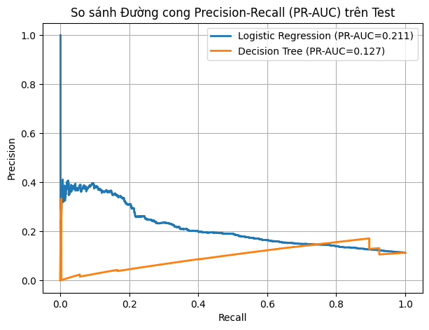

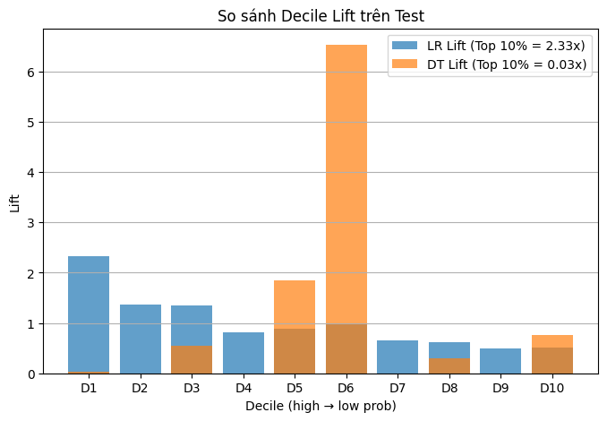

### 8C — So sánh Mức độ Quan trọng của Đặc trưng

Đây là biểu đồ so sánh các yếu tố mà hai mô hình cho là quan trọng nhất.

- **LR (Trái):** Hiển thị Odds Ratio (Hệ số `exp(coef)`). Cho thấy *mức độ ảnh hưởng* (tăng/giảm khả năng "yes").
- **DT (Phải):** Hiển thị Gini Importance. Cho thấy *sức mạnh phân loại* của đặc trưng.

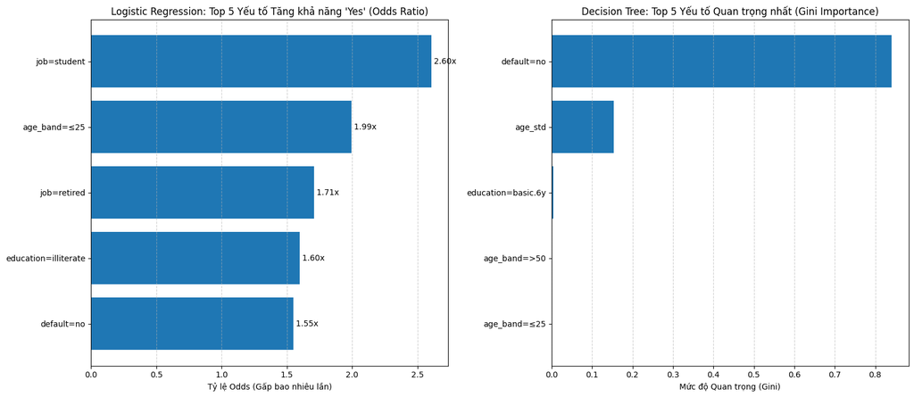

### 8D — Kết luận & Đề xuất

**Phân tích so sánh:**

**Lựa chọn Mô hình Tối ưu:**

- **Mô hình tốt nhất để Xếp hạng (Scoring):** **Logistic Regression**.
- **Mô hình tốt nhất để Phân khúc (Segmentation):** **Decision Tree** (với `maxDepth=3`) cung cấp các quy tắc đơn giản và dễ hiểu.

**Đề xuất Hành động (Phân khúc Khách hàng Ưu tiên):**